# Modeling and prediction for movies

Shaohan Wang

08/19/2020

## Front Matter

```r
# clean up workspace environment
rm(list = ls())
```

## Setup

### Load packages

```r
library(ggplot2)
library(dplyr)
library(statsr)
library(GGally)
```

### Load data

```r
load("movies.Rdata")
```

## Part 1: Data

- movies dataset has 651 observations with 32 variables and include randomly sampled movies produced and released before 2016.
- Each case here corresponds to an individual movie with detailed information. This dataset are collected mainly based on observation which means there is no random assignment, so we cannot establish causality. Besides, because the movies included are randomly selected, we can conclude generalizability to all of movies produced and released before 2016. However, we may consider convenience sampling bias here because some movies’ information may be much easier to obtain.

## Part 2: Research question

**Is there an association among ratings on IMDB and the number of votes on IMDB, whether or not the movie was nominated for a best picture Oscar, audience score on Rotten Tomatoes, critics score on Rotten Tomatoes?**

- This question allows us to predict the movie ratings on IMDB by using multiple linear regression model with some specific and appropriate explanatory variables in this dataset. The variables used here are imdb_rating, imdb_num_votes, critics_score, audience_score, best_pic_nom.

## Part 3: Exploratory data analysis

```r
# find whether or not the movie was nominated for a best picture Oscar will significantly influence the ratings and the number of voters
movies %>%
  group_by(best_pic_nom) %>%
  summarise(mean_rating = mean(imdb_rating),
            mean_number_voters = mean(imdb_num_votes),
            mean_critics_score = mean(critics_score),
            mean_audience_score = mean(audience_score))
```

```
## # A tibble: 2 x 5
##   best_pic_nom mean_rating mean_number_vote~ mean_critics_sco~ mean_audience_sc~
##   <fct>              <dbl>             <dbl>             <dbl>             <dbl>
## 1 no                  6.45            50668.              56.6              61.6
## 2 yes                 7.75           253804.              87.5              85.3
```

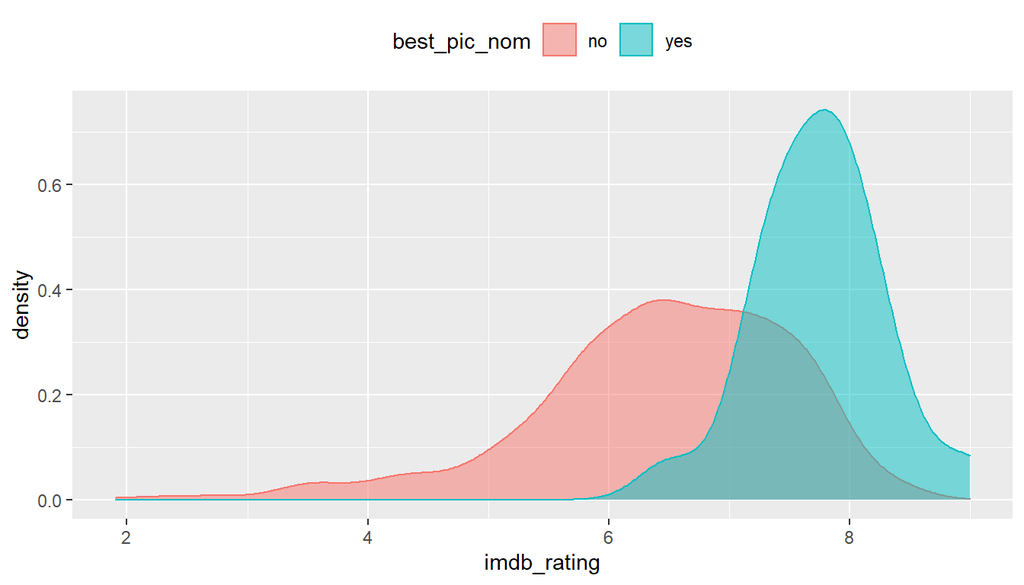

```r
# visualization
movies %>%
  ggplot(aes(x = imdb_rating)) +
  geom_density(aes(fill = best_pic_nom, color = best_pic_nom), alpha = 0.5) +
  theme(legend.position = "top")
```

- According to the graph, movies which were nominated for a best picture Oscar have relatively higher ratings on IMDB. Besides, we also find that those movies have relatively more voters on IMDB and higher critics’ scores and audience’s scores on Rotten Tomatoes.

## Part 4: Modeling

```r
# check collinearity
movies %>%
  summarise(cor(imdb_num_votes, critics_score),
            cor(imdb_num_votes, audience_score),
            cor(critics_score, audience_score)) # remove audience_score because of the collinearity
```

```
## # A tibble: 1 x 3
##   `cor(imdb_num_votes, crit~ `cor(imdb_num_votes, aud~ `cor(critics_score, audi~
##                        <dbl>                     <dbl>                     <dbl>
## 1                      0.209                     0.290                     0.704
```

```r
# set the model
model <- lm(imdb_rating ~ imdb_num_votes + critics_score + best_pic_nom, data = movies)
summary(model) # remove best_pic_nom because it is not statistically significant
```

```
##
## Call:
## lm(formula = imdb_rating ~ imdb_num_votes + critics_score + best_pic_nom,
##     data = movies)
##
## Residuals:
##      Min       1Q   Median       3Q      Max
## -3.04571 -0.35424  0.02723  0.42666  2.48067
##
## Coefficients:
##                  Estimate Std. Error t value Pr(>|t|)
## (Intercept)     4.795e+00  6.023e-02  79.614  < 2e-16 ***
## imdb_num_votes  1.679e-06  2.525e-07   6.650 6.23e-11 ***
## critics_score   2.770e-02  9.605e-04  28.837  < 2e-16 ***
## best_pic_nomyes 1.065e-01  1.561e-01   0.682    0.496
## ---
## Signif. codes:  0 '***' 0.001 '**' 0.01 '*' 0.05 '.' 0.1 ' ' 1
##
## Residual standard error: 0.6736 on 647 degrees of freedom
## Multiple R-squared:  0.6162, Adjusted R-squared:  0.6144
## F-statistic: 346.2 on 3 and 647 DF,  p-value: < 2.2e-16
```

```r
# build our final model
model2 <- lm(imdb_rating ~ imdb_num_votes + critics_score, data = movies)
summary(model2)
```

```
##
## Call:
## lm(formula = imdb_rating ~ imdb_num_votes + critics_score, data = movies)
##
## Residuals:
##      Min       1Q   Median       3Q      Max
## -3.04499 -0.33988  0.02507  0.43065  2.48448
##
## Coefficients:
##                 Estimate Std. Error t value Pr(>|t|)
## (Intercept)    4.790e+00  5.983e-02  80.070  < 2e-16 ***
## imdb_num_votes 1.731e-06  2.409e-07   7.185 1.85e-12 ***
## critics_score  2.779e-02  9.509e-04  29.223  < 2e-16 ***
## ---
## Signif. codes:  0 '***' 0.001 '**' 0.01 '*' 0.05 '.' 0.1 ' ' 1
##
## Residual standard error: 0.6733 on 648 degrees of freedom
## Multiple R-squared:  0.6159, Adjusted R-squared:  0.6147
## F-statistic: 519.5 on 2 and 648 DF,  p-value: < 2.2e-16
```

```r
model2[['model']] # view the model
```

[output not shown]

[output cut: 637 more lines]

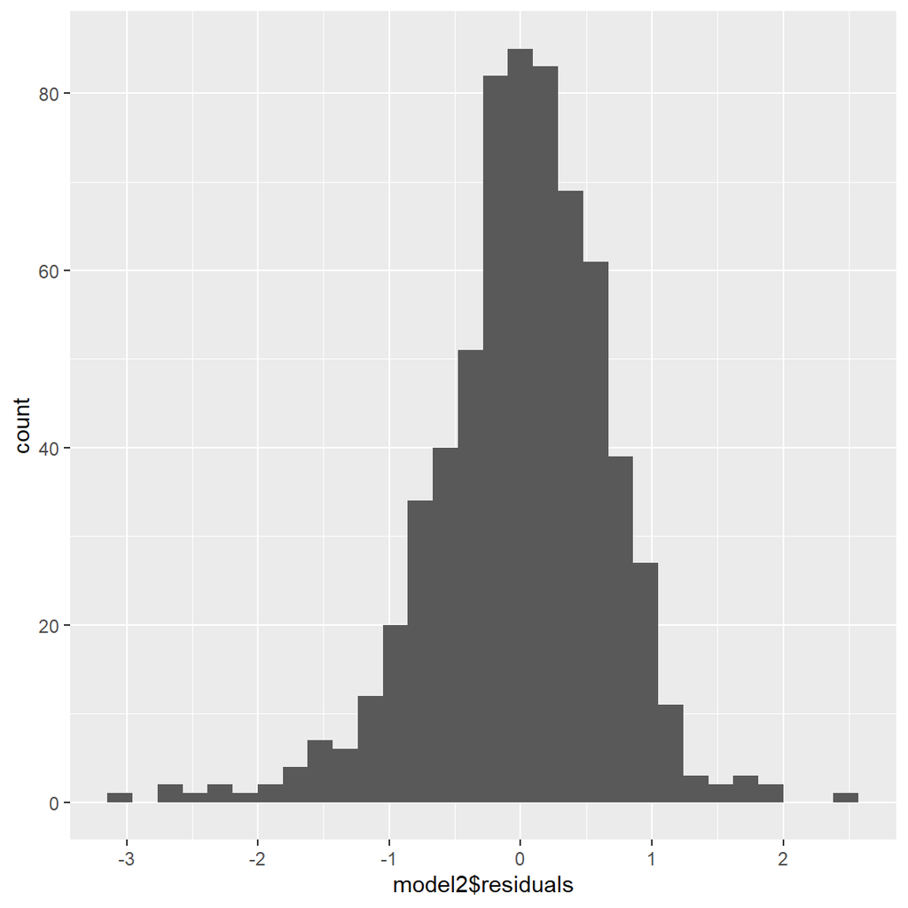

```r
# use diagnostic plot to check the conditions for this model
ggplot(data = model2, aes(x = model2$residuals)) +
         geom_histogram()
```

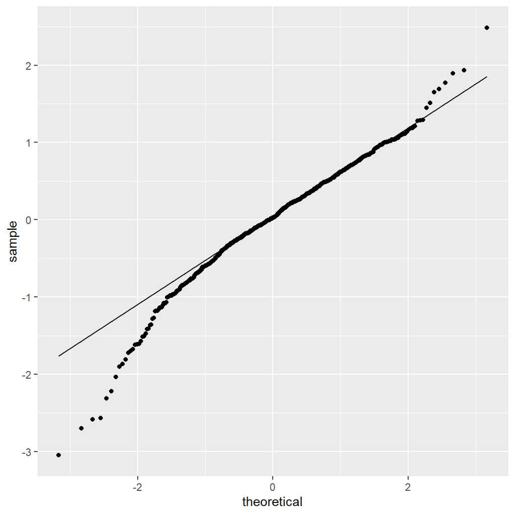

```r
ggplot(data = model2, aes(sample = .resid)) +
  stat_qq() +
  stat_qq_line() # nearly normal
```

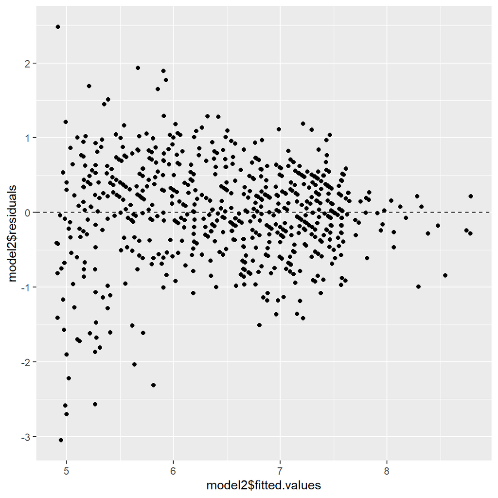

```r
ggplot() +
  geom_point(aes(x = model2$fitted.values, y = model2$residuals)) +
  geom_hline(yintercept = 0, linetype = "dashed") # constant variability
```

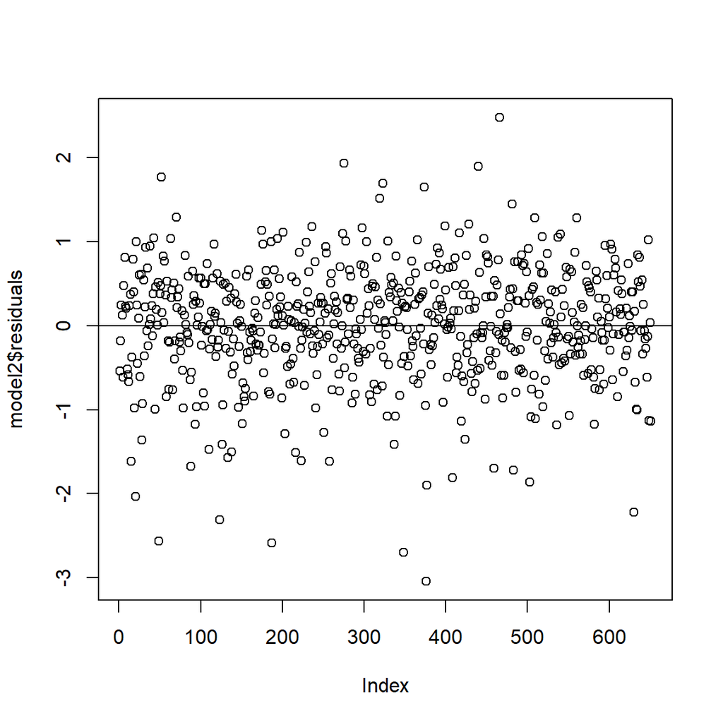

```r
plot(model2$residuals)
abline(h = 0) # independence residuals
```

- By checking collinearity, we remove the predictor audience_score because we will have nothing new by adding it in our model. Besides, by using backward elimination, we remove the explanatory variable best_pic_nom due to the high p-value. Also, by using diagnostic plots, we can conclude that the conditions for this model are reasonable. Hence, now we obtain our multiple linear regression model with all significant predictors.

## Part 5: Prediction

```r
# Pick a movie from 2016
Zootopia <- data.frame(imdb_num_votes = as.integer(420164), critics_score = as.numeric(98))

# do the prediction by our model
predict(model2, Zootopia)
```

```
##        1
## 8.240908
```

```r
# construct a prediction interval
predict(model2, Zootopia, interval = "prediction", level = 0.95)
```

```
##        fit      lwr      upr
## 1 8.240908 6.906549 9.575267
```